# Peer-graded Assignment: Prediction Assignment Writeup

Date [2021-02-20]

# 1 Executive Summary

The use of collected data from accelerometers on the belt, forearm, arm, and dumbell of 6 participants allowed us to build two models

- XGB (Gradient Boosting) with accuracy of 99,9 %
- Random forest (RF) with accuracy of 99,8 %

which we used to predict the 20 different test cases provided.

# 2 Exploratory data analyses

We explore the provided data sets (training and test) to get an idea of the variables present and their characteristics

## 2.1 Training set

**Observations** : 19622

**Variables** : 160

| Type | Name | N_missing | Complete_rate |
| --- | --- | --- | --- |
| character | user_name | 0 | 1.000 |
| character | cvtd_timestamp | 0 | 1.000 |
| character | new_window | 0 | 1.000 |
| character | kurtosis_roll_belt | 19216 | 0.021 |
| character | kurtosis_picth_belt | 19216 | 0.021 |
| character | kurtosis_yaw_belt | 19216 | 0.021 |
| character | skewness_roll_belt | 19216 | 0.021 |
| character | skewness_roll_belt.1 | 19216 | 0.021 |
| character | skewness_yaw_belt | 19216 | 0.021 |
| character | max_yaw_belt | 19216 | 0.021 |
| character | min_yaw_belt | 19216 | 0.021 |
| character | amplitude_yaw_belt | 19216 | 0.021 |
| character | kurtosis_picth_arm | 19216 | 0.021 |
| character | kurtosis_yaw_arm | 19216 | 0.021 |
| character | skewness_pitch_arm | 19216 | 0.021 |
| character | skewness_yaw_arm | 19216 | 0.021 |
| character | kurtosis_yaw_dumbbell | 19216 | 0.021 |
| character | skewness_yaw_dumbbell | 19216 | 0.021 |
| character | kurtosis_roll_forearm | 19216 | 0.021 |
| character | kurtosis_picth_forearm | 19216 | 0.021 |
| character | kurtosis_yaw_forearm | 19216 | 0.021 |
| character | skewness_roll_forearm | 19216 | 0.021 |
| character | skewness_pitch_forearm | 19216 | 0.021 |
| character | skewness_yaw_forearm | 19216 | 0.021 |
| character | max_yaw_forearm | 19216 | 0.021 |
| character | min_yaw_forearm | 19216 | 0.021 |
| character | amplitude_yaw_forearm | 19216 | 0.021 |
| character | classe | 0 | 1.000 |
| numeric | X1 | 0 | 1.000 |
| numeric | raw_timestamp_part_1 | 0 | 1.000 |

[output cut: 130 more lines]

We note the presence of

- many columns with a high percentage of values NA
- variables with temporal information that for sure are not necessary to our objective
- textual variables that do not carry informative content to our objective

## 2.2 Test set

**Observations** : 20

**Variables** : 160

| Type | Name | N_missing | Complete_rate |
| --- | --- | --- | --- |
| character | user_name | 0 | 1 |
| character | cvtd_timestamp | 0 | 1 |
| character | new_window | 0 | 1 |
| logical | kurtosis_roll_belt | 20 | 0 |
| logical | kurtosis_picth_belt | 20 | 0 |
| logical | kurtosis_yaw_belt | 20 | 0 |
| logical | skewness_roll_belt | 20 | 0 |
| logical | skewness_roll_belt.1 | 20 | 0 |
| logical | skewness_yaw_belt | 20 | 0 |
| logical | max_roll_belt | 20 | 0 |
| logical | max_picth_belt | 20 | 0 |
| logical | max_yaw_belt | 20 | 0 |
| logical | min_roll_belt | 20 | 0 |
| logical | min_pitch_belt | 20 | 0 |
| logical | min_yaw_belt | 20 | 0 |
| logical | amplitude_roll_belt | 20 | 0 |
| logical | amplitude_pitch_belt | 20 | 0 |
| logical | amplitude_yaw_belt | 20 | 0 |
| logical | var_total_accel_belt | 20 | 0 |
| logical | avg_roll_belt | 20 | 0 |
| logical | stddev_roll_belt | 20 | 0 |
| logical | var_roll_belt | 20 | 0 |
| logical | avg_pitch_belt | 20 | 0 |
| logical | stddev_pitch_belt | 20 | 0 |
| logical | var_pitch_belt | 20 | 0 |
| logical | avg_yaw_belt | 20 | 0 |
| logical | stddev_yaw_belt | 20 | 0 |
| logical | var_yaw_belt | 20 | 0 |
| logical | var_accel_arm | 20 | 0 |
| logical | avg_roll_arm | 20 | 0 |

[output cut: 130 more lines]

Same conclusions as above.

## 2.3 Outcome distribution

We see, within the training set, how is distributed the variable that will be the object of prediction :

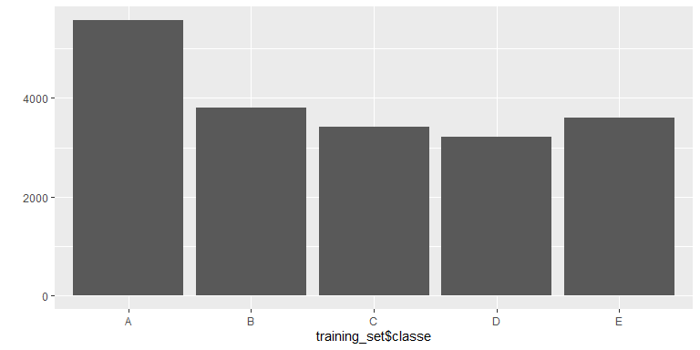

```r
qplot(training_set$classe)
```

# 3 Tidying data

## 3.1 Remove high percentage NA columns

We eliminate the columns that have a high percentage of NA values: from the EDA it results that, for the columns that have NA values, the percentage of NA is very high, therefore we proceed to eliminate all the columns that contain NA

```r
 # training
training_set_1 <- training_set[ , colSums(is.na(training_set)) == 0]

 # test
test_set_1     <- test_set[ , colSums(is.na(training_set)) == 0]
```

## 3.2 Remove uneccesary columns

We delete those columns that are not needed :

- columns with “temporal information”
- columns of character type that are not significant
- other anomalies

```r
columnsToRemove <- c(1,2,3,4,5,6)
colnames(training_set_1)[columnsToRemove]
## [1] "X1"                   "user_name"            "raw_timestamp_part_1"
## [4] "raw_timestamp_part_2" "cvtd_timestamp"       "new_window"
colnames(test_set_1)[columnsToRemove]
## [1] "X1"                   "user_name"            "raw_timestamp_part_1"
## [4] "raw_timestamp_part_2" "cvtd_timestamp"       "new_window"

 # training
training_set_1 <- training_set_1[,-columnsToRemove]

 # test
test_set_1 <- test_set_1[,-columnsToRemove]
```

## 3.3 Transform to Factors

We transform the variable “class” into factor, setting the “levels” appropriately to maintain the significance of the information

```r
t <- table(training_set_1$classe)
classeLevels <- names(t)
training_set_1$classe <- factor(training_set_1$classe, labels=classeLevels)
```

## 3.4 Tidy dataset

### 3.4.1 Tidy Training set

**Observations** : 19622

**Variables** : 54

| Type | Name | N_missing | Complete_rate |
| --- | --- | --- | --- |
| factor | classe | 0 | 1 |
| numeric | num_window | 0 | 1 |
| numeric | roll_belt | 0 | 1 |
| numeric | pitch_belt | 0 | 1 |
| numeric | yaw_belt | 0 | 1 |
| numeric | total_accel_belt | 0 | 1 |
| numeric | gyros_belt_x | 0 | 1 |
| numeric | gyros_belt_y | 0 | 1 |
| numeric | gyros_belt_z | 0 | 1 |
| numeric | accel_belt_x | 0 | 1 |
| numeric | accel_belt_y | 0 | 1 |
| numeric | accel_belt_z | 0 | 1 |
| numeric | magnet_belt_x | 0 | 1 |
| numeric | magnet_belt_y | 0 | 1 |
| numeric | magnet_belt_z | 0 | 1 |
| numeric | roll_arm | 0 | 1 |
| numeric | pitch_arm | 0 | 1 |
| numeric | yaw_arm | 0 | 1 |
| numeric | total_accel_arm | 0 | 1 |
| numeric | gyros_arm_x | 0 | 1 |
| numeric | gyros_arm_y | 0 | 1 |
| numeric | gyros_arm_z | 0 | 1 |
| numeric | accel_arm_x | 0 | 1 |
| numeric | accel_arm_y | 0 | 1 |
| numeric | accel_arm_z | 0 | 1 |
| numeric | magnet_arm_x | 0 | 1 |
| numeric | magnet_arm_y | 0 | 1 |
| numeric | magnet_arm_z | 0 | 1 |
| numeric | roll_dumbbell | 0 | 1 |
| numeric | pitch_dumbbell | 0 | 1 |
| numeric | yaw_dumbbell | 0 | 1 |
| numeric | total_accel_dumbbell | 0 | 1 |
| numeric | gyros_dumbbell_x | 0 | 1 |
| numeric | gyros_dumbbell_y | 0 | 1 |
| numeric | gyros_dumbbell_z | 0 | 1 |
| numeric | accel_dumbbell_x | 0 | 1 |
| numeric | accel_dumbbell_y | 0 | 1 |
| numeric | accel_dumbbell_z | 0 | 1 |
| numeric | magnet_dumbbell_x | 0 | 1 |
| numeric | magnet_dumbbell_y | 0 | 1 |
| numeric | magnet_dumbbell_z | 0 | 1 |
| numeric | roll_forearm | 0 | 1 |
| numeric | pitch_forearm | 0 | 1 |
| numeric | yaw_forearm | 0 | 1 |
| numeric | total_accel_forearm | 0 | 1 |
| numeric | gyros_forearm_x | 0 | 1 |
| numeric | gyros_forearm_y | 0 | 1 |
| numeric | gyros_forearm_z | 0 | 1 |
| numeric | accel_forearm_x | 0 | 1 |
| numeric | accel_forearm_y | 0 | 1 |
| numeric | accel_forearm_z | 0 | 1 |
| numeric | magnet_forearm_x | 0 | 1 |
| numeric | magnet_forearm_y | 0 | 1 |
| numeric | magnet_forearm_z | 0 | 1 |

### 3.4.2 Tidy Test set

**Observations** : 20

**Variables** : 54

| Type | Name | N_missing | Complete_rate |
| --- | --- | --- | --- |
| numeric | num_window | 0 | 1 |
| numeric | roll_belt | 0 | 1 |
| numeric | pitch_belt | 0 | 1 |
| numeric | yaw_belt | 0 | 1 |
| numeric | total_accel_belt | 0 | 1 |
| numeric | gyros_belt_x | 0 | 1 |
| numeric | gyros_belt_y | 0 | 1 |
| numeric | gyros_belt_z | 0 | 1 |
| numeric | accel_belt_x | 0 | 1 |
| numeric | accel_belt_y | 0 | 1 |
| numeric | accel_belt_z | 0 | 1 |
| numeric | magnet_belt_x | 0 | 1 |
| numeric | magnet_belt_y | 0 | 1 |
| numeric | magnet_belt_z | 0 | 1 |
| numeric | roll_arm | 0 | 1 |
| numeric | pitch_arm | 0 | 1 |
| numeric | yaw_arm | 0 | 1 |
| numeric | total_accel_arm | 0 | 1 |
| numeric | gyros_arm_x | 0 | 1 |
| numeric | gyros_arm_y | 0 | 1 |
| numeric | gyros_arm_z | 0 | 1 |
| numeric | accel_arm_x | 0 | 1 |
| numeric | accel_arm_y | 0 | 1 |
| numeric | accel_arm_z | 0 | 1 |
| numeric | magnet_arm_x | 0 | 1 |
| numeric | magnet_arm_y | 0 | 1 |
| numeric | magnet_arm_z | 0 | 1 |
| numeric | roll_dumbbell | 0 | 1 |
| numeric | pitch_dumbbell | 0 | 1 |
| numeric | yaw_dumbbell | 0 | 1 |
| numeric | total_accel_dumbbell | 0 | 1 |
| numeric | gyros_dumbbell_x | 0 | 1 |
| numeric | gyros_dumbbell_y | 0 | 1 |
| numeric | gyros_dumbbell_z | 0 | 1 |
| numeric | accel_dumbbell_x | 0 | 1 |
| numeric | accel_dumbbell_y | 0 | 1 |
| numeric | accel_dumbbell_z | 0 | 1 |
| numeric | magnet_dumbbell_x | 0 | 1 |
| numeric | magnet_dumbbell_y | 0 | 1 |
| numeric | magnet_dumbbell_z | 0 | 1 |
| numeric | roll_forearm | 0 | 1 |
| numeric | pitch_forearm | 0 | 1 |
| numeric | yaw_forearm | 0 | 1 |
| numeric | total_accel_forearm | 0 | 1 |
| numeric | gyros_forearm_x | 0 | 1 |
| numeric | gyros_forearm_y | 0 | 1 |
| numeric | gyros_forearm_z | 0 | 1 |
| numeric | accel_forearm_x | 0 | 1 |
| numeric | accel_forearm_y | 0 | 1 |
| numeric | accel_forearm_z | 0 | 1 |
| numeric | magnet_forearm_x | 0 | 1 |
| numeric | magnet_forearm_y | 0 | 1 |
| numeric | magnet_forearm_z | 0 | 1 |
| numeric | problem_id | 0 | 1 |

# 4 Predictive models

We are going to build a model for each of these following techniques

- Linear discriminant analysis (LDA)
- Gradient Boosting (XGB)
- Random forest (RF)

Once constructed a model we will go to verify its “performance” and we will supply some information on it

- confusion matrix
- accuracy
- kappa
- other model specific information

## 4.1 Preliminaries

### 4.1.1 Discovering features correlation

Correlation matrix chart with relative significance thresholds via p-value: cluster ordering and significance level threshold set to 0.05 (*leave blank on no significant coefficient*)

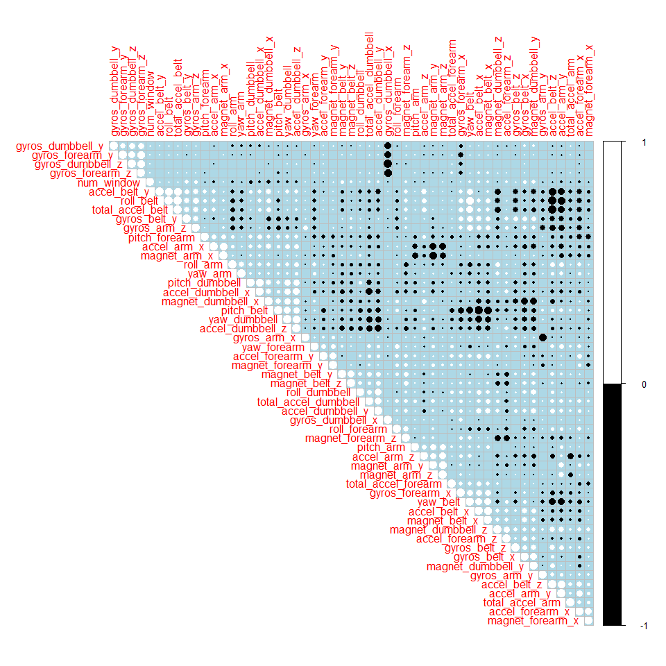

```r
 # correlation plot with significance level threshold
corrplot(corrMatrix, order="hclust", type="upper",col=c("black", "white"),
         bg="lightblue",p.mat = pValueMatrix, sig.level = 0.05, insig = "blank")
```

### 4.1.2 Splitting the training set

We divide the training set in two parts

- one will be used in order to construct the models with the technique of the cross-validation
- the other one will be use in order to verify the accuracy (in the prediction) of the constructed models

```r
training_samples <- createDataPartition(training_set_tidy$classe, p = 3/4, list = FALSE)
training_set <- training_set_tidy[training_samples,]
testing_set <- training_set_tidy[-training_samples,]
```

### 4.1.3 Cross-validation

To build the models we will use the technique of cross-validation. Briefly, cross-validation algorithms can be summarized as follow:

```
* Split the training set to reserve a small sample of the data set
* Build (or train) the model using the remaining part of the data set
* Test the effectiveness of the model on the the reserved sample of the data set
```

We will use the K-fold cross-validation

The k-fold cross-validation method evaluates the model performance on different subset of the training data and then calculate the average prediction error rate. The algorithm is as follow:

```
* Randomly split the data set into k-subsets (or k-fold) (for example 5 subsets)
* Reserve one subset and train the model on all other subsets
* Test the model on the reserved subset and record the prediction error
* Repeat this process until each of the k subsets has served as the test set
* Compute the average of the k recorded errors.
  This is called the cross-validation error serving as the performance metric for the model.
```

```r
control <- trainControl(method = "cv", number = 5)
performance_metric <- "Accuracy"
```

## 4.2 Model Building

### 4.2.1 Linear discriminant analysis (LDA)

Linear discriminant analysis (LDA) uses linear combinations of predictors to predict the class of a given observation. Assumes that the predictor variables (p) are normally distributed and the classes have identical variances (for univariate analysis, p = 1) or identical covariance matrices (for multivariate analysis, p > 1).

#### 4.2.1.1 Summary

```r
LDA
## Linear Discriminant Analysis
##
## 14718 samples
##    53 predictor
##     5 classes: 'A', 'B', 'C', 'D', 'E'
##
## No pre-processing
## Resampling: Cross-Validated (5 fold)
## Summary of sample sizes: 11774, 11774, 11776, 11774, 11774
## Resampling results:
##
##   Accuracy   Kappa
##   0.7157899  0.6403593
```

#### 4.2.1.2 Prediction

```r
LDA_prediction <- predict(LDA, testing_set)
head(LDA_prediction)
## [1] A A A A A A
## Levels: A B C D E
```

#### 4.2.1.3 Confusion Matrix

```
## Confusion Matrix and Statistics
##
##           Reference
## Prediction    A    B    C    D    E
##          A 1141  133   79   39   37
##          B   34  633  107   40  150
##          C   98  106  545  108   69
##          D  114   31  101  593   87
##          E    8   46   23   24  558
##
## Overall Statistics
##
##                Accuracy : 0.7076
##                  95% CI : (0.6946, 0.7203)
##     No Information Rate : 0.2845
##     P-Value [Acc > NIR] : < 2.2e-16
##
##                   Kappa : 0.6301
##
##  Mcnemar's Test P-Value : < 2.2e-16
##
## Statistics by Class:
##
##                      Class: A Class: B Class: C Class: D Class: E
## Sensitivity            0.8179   0.6670   0.6374   0.7376   0.6193
## Specificity            0.9179   0.9163   0.9059   0.9188   0.9748
## Pos Pred Value         0.7985   0.6566   0.5886   0.6404   0.8467
## Neg Pred Value         0.9269   0.9198   0.9221   0.9470   0.9192
## Prevalence             0.2845   0.1935   0.1743   0.1639   0.1837
## Detection Rate         0.2327   0.1291   0.1111   0.1209   0.1138
## Detection Prevalence   0.2914   0.1966   0.1888   0.1888   0.1344
## Balanced Accuracy      0.8679   0.7917   0.7717   0.8282   0.7970
```

The above results show different statistical metrics among which the most important include:

```
- cross-tabulation between prediction and reference known outcome
- model accuracy of 0.7075856%
- kappa of 0.6300899%, which is the accuracy corrected for chance.
```

### 4.2.2 Gradient Boosting (XGB)

Boosting, which is similar to the bagging method, except that the trees are grown sequentially: each successive tree is grown using information from previously grown trees, with the aim to minimize the error of the previous models

For example, given a current regression tree model, the procedure is as follow:

```
* Fit a decision tree using the model residual errors as the outcome variable
* Add this new decision tree, adjusted by a shrinkage parameter lambda, into the fitted function in order
  to update the residuals.lambda is a small positive value, typically comprised between 0.01 and 0.001.
```

This approach results in slowly and successively improving the fitted the model resulting a very performant model. Boosting has different tuning parameters including:

```
* The number of trees B
* The shrinkage parameter lambda
* The number of splits in each tree
```

There are different variants of boosting, including Adaboost, gradient boosting and stochastic gradient boosting.

Stochastic gradient boosting, implemented in the R package xgboost, is the most commonly used boosting technique, which involves resampling of observations and columns in each round. It offers the best performance. xgboost stands for extremely gradient boosting. Boosting can be used for both classification and regression problems.

#### 4.2.2.1 Summary

Best tuning parameters

```r
XGB$bestTune
```

|  | nrounds | max_depth | eta | gamma | colsample_bytree | min_child_weight | subsample |
| --- | --- | --- | --- | --- | --- | --- | --- |
| 108 | 150 | 3 | 0.4 | 0 | 0.8 | 1 | 1 |

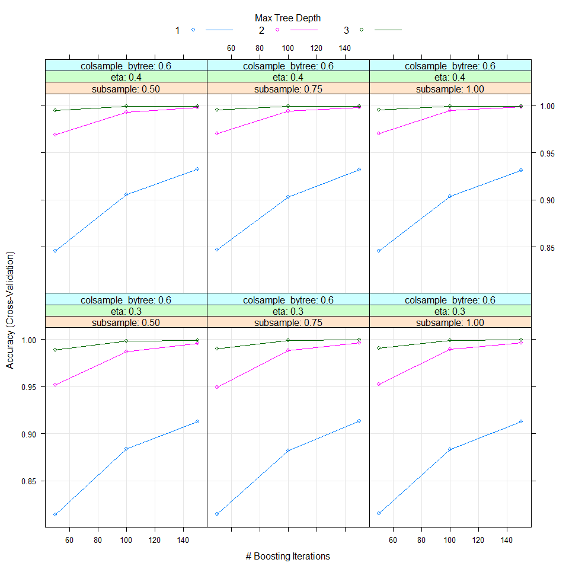

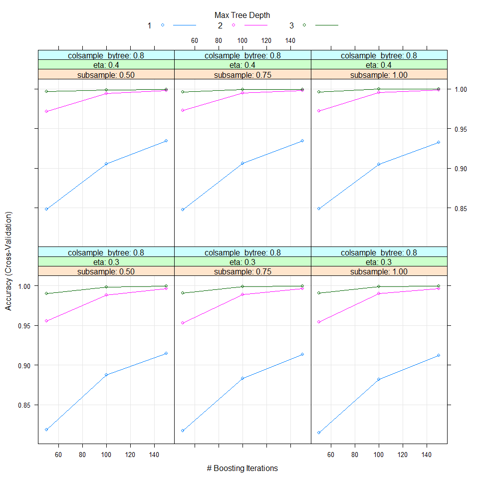

```r
plot(XGB)
```

Importance of variables in percentage

```r
varImp(XGB)
## xgbTree variable importance
##
##   only 20 most important variables shown (out of 53)
##
##                   Overall
## num_window        100.000
## roll_belt          44.879
## yaw_belt           27.299
## magnet_dumbbell_y  23.408
## pitch_forearm      21.075
## magnet_dumbbell_z  16.505
## accel_belt_z       15.492
## roll_forearm       15.198
## magnet_belt_z      12.197
## accel_dumbbell_y   12.050
## pitch_belt         10.432
## accel_forearm_x     7.849
## magnet_arm_x        6.497
## magnet_forearm_z    6.390
## magnet_dumbbell_x   5.731
## gyros_belt_z        5.619
## magnet_belt_x       5.310
## gyros_dumbbell_y    5.155
## accel_dumbbell_z    4.941
## accel_forearm_z     4.831
```

#### 4.2.2.2 Prediction

```r
XGB_prediction<- predict(XGB, testing_set)
head(XGB_prediction)
## [1] A A A A A A
## Levels: A B C D E
```

#### 4.2.2.3 Confusion Matrix

```
## Confusion Matrix and Statistics
##
##           Reference
## Prediction    A    B    C    D    E
##          A 1395    0    0    0    0
##          B    0  949    1    0    0
##          C    0    0  854    0    0
##          D    0    0    0  803    0
##          E    0    0    0    1  901
##
## Overall Statistics
##
##                Accuracy : 0.9996
##                  95% CI : (0.9985, 1)
##     No Information Rate : 0.2845
##     P-Value [Acc > NIR] : < 2.2e-16
##
##                   Kappa : 0.9995
##
##  Mcnemar's Test P-Value : NA
##
## Statistics by Class:
##
##                      Class: A Class: B Class: C Class: D Class: E
## Sensitivity            1.0000   1.0000   0.9988   0.9988   1.0000
## Specificity            1.0000   0.9997   1.0000   1.0000   0.9998
## Pos Pred Value         1.0000   0.9989   1.0000   1.0000   0.9989
## Neg Pred Value         1.0000   1.0000   0.9998   0.9998   1.0000
## Prevalence             0.2845   0.1935   0.1743   0.1639   0.1837
## Detection Rate         0.2845   0.1935   0.1741   0.1637   0.1837
## Detection Prevalence   0.2845   0.1937   0.1741   0.1637   0.1839
## Balanced Accuracy      1.0000   0.9999   0.9994   0.9994   0.9999
```

The above results show different statistical metrics among which the most important include:

```
- cross-tabulation between prediction and reference known outcome
- model accuracy of 0.9995922%
- kappa of 0.9994841%, which is the accuracy corrected for chance.
```

### 4.2.3 Random forest (RF)

Random Forest algorithm, is one of the most commonly used and the most powerful machine learning techniques. It is a special type of bagging applied to decision trees.

Compared to the standard CART model the random forest provides a strong improvement, which consists of applying bagging to the data and bootstrap sampling to the predictor variables at each split. This means that at each splitting step of the tree algorithm, a random sample of n predictors is chosen as split candidates from the full set of the predictors.

Random forest can be used for both classification (predicting a categorical variable) and regression (predicting a continuous variable).

#### 4.2.3.1 Summary

```r
RF
## Random Forest
##
## 14718 samples
##    53 predictor
##     5 classes: 'A', 'B', 'C', 'D', 'E'
##
## No pre-processing
## Resampling: Cross-Validated (5 fold)
## Summary of sample sizes: 11774, 11775, 11774, 11775, 11774
## Resampling results across tuning parameters:
##
##   mtry  Accuracy   Kappa
##    2    0.9953117  0.9940694
##   27    0.9974182  0.9967343
##   53    0.9952438  0.9939838
##
## Accuracy was used to select the optimal model using the largest value.
## The final value used for the model was mtry = 27.
```

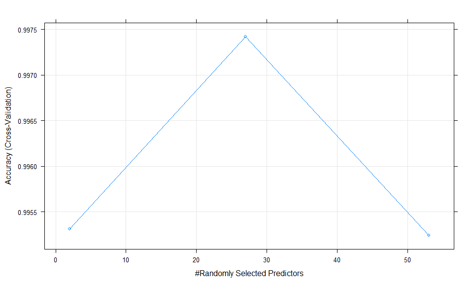

```r
plot(RF)
```

Result

```r
RF$results
```

|  | mtry | Accuracy | Kappa | AccuracySD | KappaSD |
| --- | --- | --- | --- | --- | --- |
| 1 | 2 | 0.9953117 | 0.9940694 | 0.0015082146 | 0.0019080908 |
| 2 | 27 | 0.9974182 | 0.9967343 | 0.0006168292 | 0.0007802086 |
| 3 | 53 | 0.9952438 | 0.9939838 | 0.0012016389 | 0.0015209147 |

Final model

```r
RF$finalModel
##
## Call:
##  randomForest(x = x, y = y, mtry = param$mtry)
##                Type of random forest: classification
##                      Number of trees: 500
## No. of variables tried at each split: 27
##
##         OOB estimate of  error rate: 0.18%
## Confusion matrix:
##      A    B    C    D    E  class.error
## A 4184    0    0    0    1 0.0002389486
## B    3 2842    3    0    0 0.0021067416
## C    0    7 2560    0    0 0.0027269186
## D    0    0    7 2404    1 0.0033167496
## E    0    0    0    4 2702 0.0014781966
```

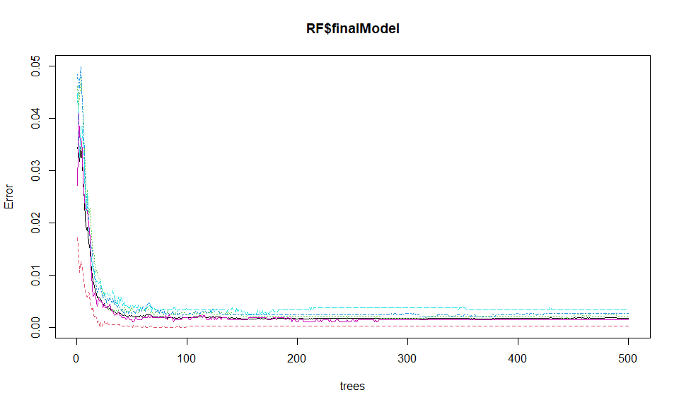

```r
plot(RF$finalModel)
```

Importance of variables

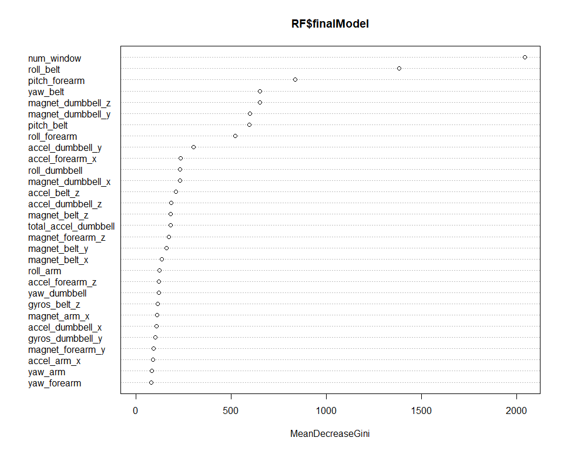

```r
varImpPlot(RF$finalModel, type = 2)
```

in percentage

```r
varImp(RF)
## rf variable importance
##
##   only 20 most important variables shown (out of 53)
##
##                      Overall
## num_window           100.000
## roll_belt             67.501
## pitch_forearm         40.439
## yaw_belt              31.315
## magnet_dumbbell_z     31.286
## magnet_dumbbell_y     28.801
## pitch_belt            28.607
## roll_forearm          24.937
## accel_dumbbell_y      14.158
## accel_forearm_x       10.837
## roll_dumbbell         10.713
## magnet_dumbbell_x     10.645
## accel_belt_z           9.597
## accel_dumbbell_z       8.316
## magnet_belt_z          8.198
## total_accel_dumbbell   8.175
## magnet_forearm_z       7.688
## magnet_belt_y          7.221
## magnet_belt_x          5.887
## roll_arm               5.373
```

#### 4.2.3.2 Prediction

```r
RF_prediction<- predict(RF, testing_set)
head(RF_prediction)
## [1] A A A A A A
## Levels: A B C D E
```

#### 4.2.3.3 Confusion Matrix

```
## Confusion Matrix and Statistics
##
##           Reference
## Prediction    A    B    C    D    E
##          A 1395    3    0    0    0
##          B    0  945    3    0    0
##          C    0    1  852    2    0
##          D    0    0    0  802    0
##          E    0    0    0    0  901
##
## Overall Statistics
##
##                Accuracy : 0.9982
##                  95% CI : (0.9965, 0.9992)
##     No Information Rate : 0.2845
##     P-Value [Acc > NIR] : < 2.2e-16
##
##                   Kappa : 0.9977
##
##  Mcnemar's Test P-Value : NA
##
## Statistics by Class:
##
##                      Class: A Class: B Class: C Class: D Class: E
## Sensitivity            1.0000   0.9958   0.9965   0.9975   1.0000
## Specificity            0.9991   0.9992   0.9993   1.0000   1.0000
## Pos Pred Value         0.9979   0.9968   0.9965   1.0000   1.0000
## Neg Pred Value         1.0000   0.9990   0.9993   0.9995   1.0000
## Prevalence             0.2845   0.1935   0.1743   0.1639   0.1837
## Detection Rate         0.2845   0.1927   0.1737   0.1635   0.1837
## Detection Prevalence   0.2851   0.1933   0.1743   0.1635   0.1837
## Balanced Accuracy      0.9996   0.9975   0.9979   0.9988   1.0000
```

The above results show different statistical metrics among which the most important include:

```
- cross-tabulation between prediction and reference known outcome
- model accuracy of 0.9981648%
- kappa of 0.9976785%, which is the accuracy corrected for chance
```

## 4.3 Model comparison

We compare the models based on level of accuracy and other characteristics

```
##
## Call:
## summary.resamples(object = models_compare)
##
## Models: LDA, XGB, RF
## Number of resamples: 5
##
## Accuracy
##          Min.   1st Qu.    Median      Mean   3rd Qu.      Max. NA's
## LDA 0.7058424 0.7134602 0.7156929 0.7157899 0.7184103 0.7255435    0
## XGB 0.9993204 0.9993204 0.9996603 0.9996602 1.0000000 1.0000000    0
## RF  0.9966033 0.9969429 0.9976215 0.9974182 0.9979613 0.9979620    0
##
## Kappa
##          Min.   1st Qu.    Median      Mean   3rd Qu.      Max. NA's
## LDA 0.6280158 0.6370944 0.6404823 0.6403593 0.6438447 0.6523591    0
## XGB 0.9991404 0.9991404 0.9995704 0.9995702 1.0000000 1.0000000    0
## RF  0.9957033 0.9961334 0.9969915 0.9967343 0.9974210 0.9974222    0
```

graphically

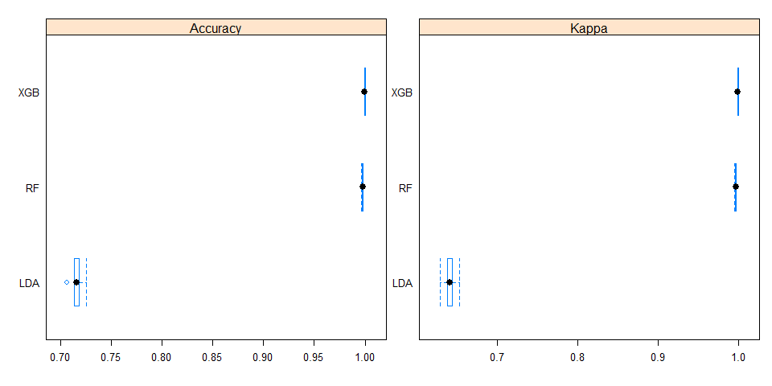

## 4.4 Conclusion

The XGB model and the RF model have high accuracy and can be considered equivalent. The LDA model does not have a satisfactory accuracy.

# 5 Prediction on Test Set

Using the three constructed models we predict the outcome “classe” on the test set provided for the project

| test_set_tidy.problem_id | LDA_answers |
| --- | --- |
| 1 | B |
| 2 | A |
| 3 | B |
| 4 | A |
| 5 | A |
| 6 | C |
| 7 | D |
| 8 | D |
| 9 | A |
| 10 | A |

[output cut: 10 more lines]

| test_set_tidy.problem_id | RF_answers |
| --- | --- |
| 1 | B |
| 2 | A |
| 3 | B |
| 4 | A |
| 5 | A |
| 6 | E |
| 7 | D |
| 8 | B |
| 9 | A |
| 10 | A |

[output cut: 10 more lines]

| test_set_tidy.problem_id | XGB_answers |
| --- | --- |
| 1 | B |
| 2 | A |
| 3 | B |
| 4 | A |
| 5 | A |
| 6 | E |
| 7 | D |
| 8 | B |
| 9 | A |
| 10 | A |

[output cut: 10 more lines]

```
##             [,1] [,2] [,3] [,4] [,5] [,6] [,7] [,8] [,9] [,10] [,11] [,12]
## LDA_answers "B"  "A"  "B"  "A"  "A"  "C"  "D"  "D"  "A"  "A"   "D"   "A"
## RF_answers  "B"  "A"  "B"  "A"  "A"  "E"  "D"  "B"  "A"  "A"   "B"   "C"
## XGB_answers "B"  "A"  "B"  "A"  "A"  "E"  "D"  "B"  "A"  "A"   "B"   "C"
##             [,13] [,14] [,15] [,16] [,17] [,18] [,19] [,20]
## LDA_answers "B"   "A"   "B"   "A"   "A"   "B"   "B"   "B"
## RF_answers  "B"   "A"   "E"   "E"   "A"   "B"   "B"   "B"
## XGB_answers "B"   "A"   "E"   "E"   "A"   "B"   "B"   "B"
```

As we expected the prediction offered by the two models RF and XGB is concordant. The prediction of the LDA model diverges from that of the other two models.

END